# Session 3: Patterns and Output

- Show All Code
- Hide All Code
- View Source

R Programming Workbook

Author

R Programming Course

Published

April 29, 2026

**NoteLearning Objectives**

By the end of this session, you will be able to:

**Part 1: Apply Family**

- Replace loops with `lapply`, `sapply`, `vapply`
- Summarize data by groups with `tapply`
- Iterate over multiple inputs with `mapply`

**Part 2: String Handling**

- Build strings with `paste()` and `sprintf()`
- Find and replace patterns with `grep()`, `gsub()`
- Split and clean strings

**Part 3: Base R Plotting**

- Create scatter plots, histograms, bar plots, and boxplots
- Customize with colors, labels, legends, and multi-panel layouts
- Save plots to files

```r
students <- data.frame(
  name = c("Alice", "Bob", "Carlos", "Diana", "Elena", "Frank"),
  age = c(21, 23, 22, 20, 24, 21),
  major = c("CS", "Math", "CS", "Stats", "CS", "Math"),
  gpa = c(3.8, 3.2, 3.5, 3.9, 3.1, 3.6),
  year = c(3, 4, 3, 2, 4, 3)
)
```

## Part 1: The Apply Family

### 1.1 lapply: Returns a List

`lapply` applies a function to each element and always returns a list:

```r
lapply(1:4, \(x) x^2)
```

```
[[1]]
[1] 1

[[2]]
[1] 4

[[3]]
[1] 9

[[4]]
[1] 16
```

On a data frame, it iterates over columns:

```r
lapply(students[, c("age", "gpa", "year")], mean)
```

```
$age
[1] 21.83333

$gpa
[1] 3.516667

$year
[1] 3.166667
```

### 1.2 sapply: Simplifies the Output

```r
sapply(students[, c("age", "gpa", "year")], mean)
```

```
      age       gpa      year
21.833333  3.516667  3.166667
```

`sapply` tries to return a vector or matrix. Convenient but unpredictable.

### 1.3 vapply: Type-Safe

```r
vapply(students[, c("age", "gpa", "year")], mean, numeric(1))
```

```
      age       gpa      year
21.833333  3.516667  3.166667
```

You specify the expected output type. Use `vapply` in scripts and functions.

### 1.4 tapply: Group Summaries

```r
tapply(students$gpa, students$major, mean)
```

```
      CS     Math    Stats
3.466667 3.400000 3.900000
```

```r
tapply(students$age, students$year, range)
```

```
$`2`
[1] 20 20

$`3`
[1] 21 22

$`4`
[1] 23 24
```

### 1.5 mapply: Multiple Inputs

```r
mapply(\(name, gpa) paste(name, "has GPA", gpa),
       students$name, students$gpa)
```

```
               Alice                  Bob               Carlos
 "Alice has GPA 3.8"    "Bob has GPA 3.2" "Carlos has GPA 3.5"
               Diana                Elena                Frank
 "Diana has GPA 3.9"  "Elena has GPA 3.1"  "Frank has GPA 3.6"
```

### Your Turn: Exercise 1.1

Use `sapply` to compute the standard deviation of each numeric column in `students`.

**Solution**

```r
sapply(students[, c("age", "gpa", "year")], sd)
```

### Your Turn: Exercise 1.2

Use `tapply` to find:

1. The maximum GPA in each major
2. The number of students in each year

**Solution**

```r
tapply(students$gpa, students$major, max)
tapply(students$name, students$year, length)
```

### Your Turn: Exercise 1.3

Use `lapply` to apply a custom function to each numeric column that returns a named vector with `mean`, `min`, and `max`. Then convert the result to a data frame using `do.call(rbind, ...)`.

**Solution**

```r
result <- lapply(students[, c("age", "gpa", "year")], \(x) {
  c(mean = mean(x), min = min(x), max = max(x))
})
do.call(rbind, result)
```

### Your Turn: Exercise 1.4

Use `mapply` to create labels like “Alice (CS, Year 3)” for each student.

**Solution**

```r
mapply(\(n, m, y) sprintf("%s (%s, Year %d)", n, m, y),
       students$name, students$major, students$year)
```

**WarningCommon Mistake**

**Using `sapply` when output length varies.**

```r
sapply(list(a = 1:3, b = 1:5), range)  # matrix (OK)
```

```
     a b
[1,] 1 1
[2,] 3 5
```

```r
sapply(list(a = 1:3, b = 1:5), \(x) x[x > 2])  # list (surprise!)
```

```
$a
[1] 3

$b
[1] 3 4 5
```

When results have different lengths, `sapply` falls back to a list. Use `lapply` if you expect varied lengths.

**TipChallenge**

Write a function `column_report` that takes a data frame and uses `vapply` to return a character vector describing each column: “colname: type (n unique values)”.

**Solution**

```r
column_report <- function(df) {
  vapply(names(df), \(col) {
    sprintf("%s: %s (%d unique)", col, class(df[[col]]), length(unique(df[[col]])))
  }, character(1))
}
column_report(students)
```

## Part 2: String Handling

### 2.1 Building Strings

```r
paste("Hello", "World")
```

```
[1] "Hello World"
```

```r
paste("Hello", "World", sep = "-")
```

```
[1] "Hello-World"
```

```r
paste0("item_", 1:5)
```

```
[1] "item_1" "item_2" "item_3" "item_4" "item_5"
```

```r
fruits <- c("apple", "banana", "cherry")
paste(fruits, collapse = ", ")
```

```
[1] "apple, banana, cherry"
```

`sep` goes between arguments. `collapse` joins vector elements into one string.

### 2.2 Formatted Strings with sprintf()

```r
sprintf("Name: %s, GPA: %.2f", "Alice", 3.812)
```

```
[1] "Name: Alice, GPA: 3.81"
```

```r
sprintf("Student %d of %d", 1:3, 6)
```

```
[1] "Student 1 of 6" "Student 2 of 6" "Student 3 of 6"
```

Format codes: `%s` = string, `%d` = integer, `%f` = float, `%.2f` = 2 decimals.

### 2.3 Pattern Matching

```r
emails <- c("alice@uni.edu", "bob@gmail.com", "carlos@uni.edu", "diana@yahoo.com")

grep("uni", emails)               # positions
```

```
[1] 1 3
```

```r
grep("uni", emails, value = TRUE)  # values
```

```
[1] "alice@uni.edu"  "carlos@uni.edu"
```

```r
grepl("uni", emails)               # TRUE/FALSE
```

```
[1]  TRUE FALSE  TRUE FALSE
```

### 2.4 Substitution

```r
x <- "The quick brown fox"
sub("quick", "slow", x)   # first match
```

```
[1] "The slow brown fox"
```

```r
gsub("o", "0", x)          # all matches
```

```
[1] "The quick br0wn f0x"
```

```r
# Clean data
prices <- c("$10.99", "$25.50", "$7.00")
as.numeric(gsub("$", "", prices, fixed = TRUE))
```

```
[1] 10.99 25.50  7.00
```

### 2.5 Splitting Strings

```r
strsplit("2024-01-15", "-")[[1]]
```

```
[1] "2024" "01"   "15"
```

```r
strsplit(c("a,b,c", "d,e"), ",")
```

```
[[1]]
[1] "a" "b" "c"

[[2]]
[1] "d" "e"
```

`strsplit` returns a list. Use `[[1]]` for a single string input.

### Your Turn: Exercise 2.1

Given this vector of full names:

```r
full_names <- c("Alice Smith", "Bob Jones", "Carlos Garcia", "Diana Chen")
```

1. Extract just the first names (split on space, take first element)
2. Create email addresses: firstname.lastname@university.edu (all lowercase)

**Solution**

```r
# 1
sapply(strsplit(full_names, " "), \(x) x[1])

# 2
parts <- strsplit(tolower(full_names), " ")
sapply(parts, \(x) paste0(x[1], ".", x[2], "@university.edu"))
```

### Your Turn: Exercise 2.2

Clean this messy data:

```r
messy <- c("  New York  ", "los angeles", "CHICAGO", "  san Francisco")
```

Produce: `"New York", "Los Angeles", "Chicago", "San Francisco"`

**Solution**

```r
clean <- trimws(messy)
clean <- tolower(clean)
# Capitalize first letter of each word
sapply(strsplit(clean, " "), \(words) {
  paste(sapply(words, \(w) {
    paste0(toupper(substring(w, 1, 1)), substring(w, 2))
  }), collapse = " ")
})
```

### Your Turn: Exercise 2.3

Given this log data:

```r
logs <- c("2024-01-15 ERROR: file not found",
          "2024-01-15 INFO: process started",
          "2024-01-16 ERROR: connection timeout",
          "2024-01-16 INFO: process complete",
          "2024-01-17 WARNING: low memory")
```

1. Find all ERROR logs using `grepl`
2. Extract just the dates from error logs
3. Replace “ERROR” with “ERR” in all logs

**Solution**

```r
# 1
error_logs <- logs[grepl("ERROR", logs)]
error_logs

# 2
substring(error_logs, 1, 10)

# 3
gsub("ERROR", "ERR", logs)
```

**WarningCommon Mistake**

**Forgetting that `gsub()` uses pattern matching by default.**

```r
gsub(".", "!", "Hello.")  # replaces everything (not just the dot)!
```

```
[1] "!!!!!!"
```

```r
gsub(".", "!", "Hello.", fixed = TRUE)  # correct: use fixed = TRUE for literal text
```

```
[1] "Hello!"
```

By default, `gsub()` treats the pattern as a regular expression (which we will cover in Session 14). For now, add `fixed = TRUE` when you want to match exact text like `"."`, `"$"`, or `"("`.

## Part 3: Base R Plotting

### 3.1 Scatter Plot

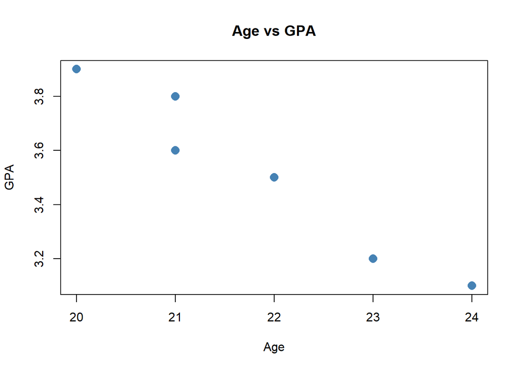

```r
plot(students$age, students$gpa,
     main = "Age vs GPA",
     xlab = "Age", ylab = "GPA",
     pch = 16, col = "steelblue", cex = 1.5)
```

Key arguments: `pch` = point shape, `col` = color, `cex` = size multiplier.

### 3.2 Line Plot

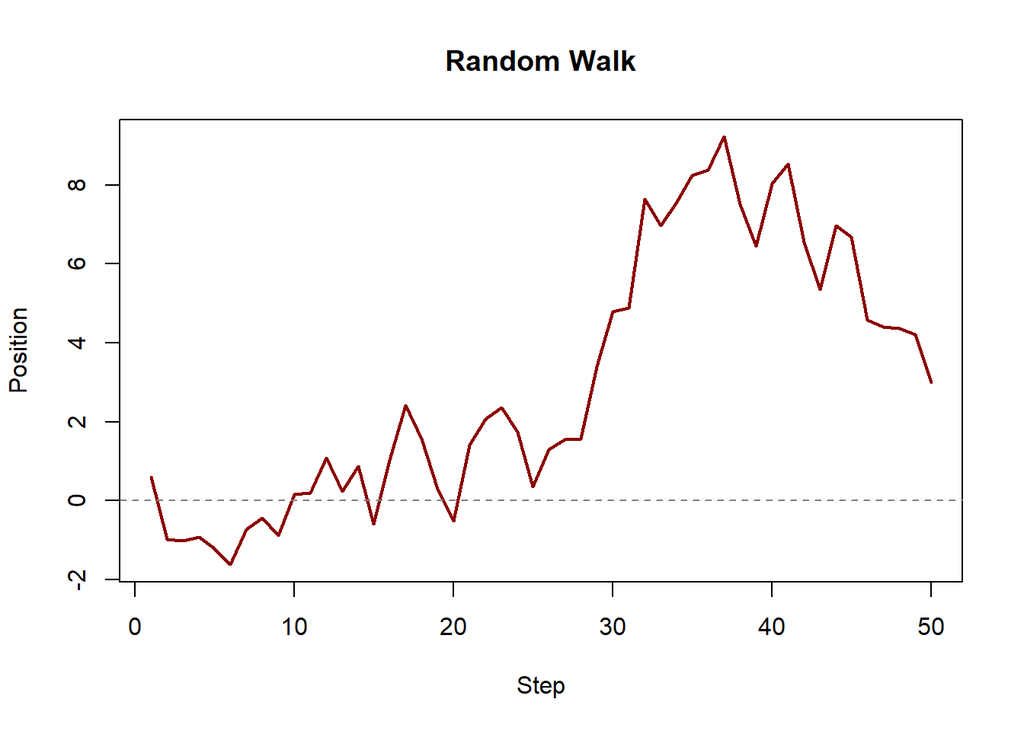

```r
x <- 1:50
y <- cumsum(rnorm(50))
plot(x, y, type = "l", col = "darkred", lwd = 2,
     main = "Random Walk", xlab = "Step", ylab = "Position")
abline(h = 0, lty = 2, col = "gray50")
```

### 3.3 Histogram

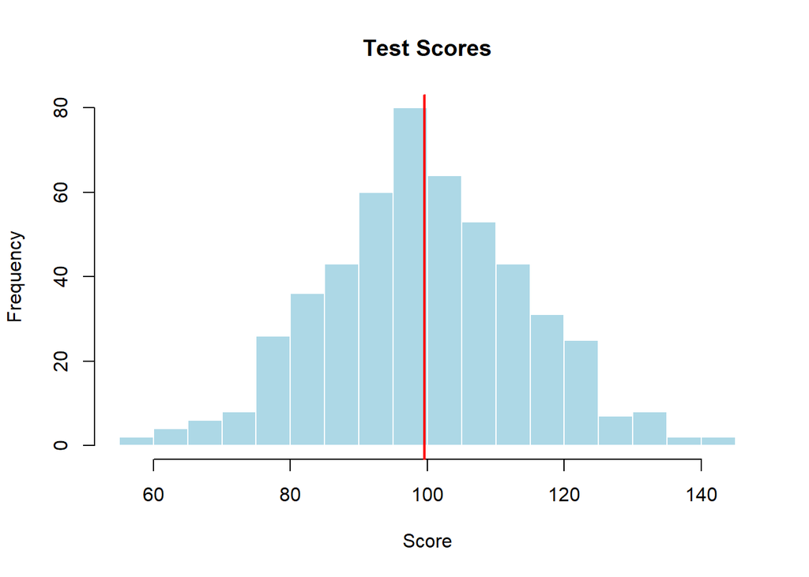

```r
set.seed(42)
data <- rnorm(500, mean = 100, sd = 15)
hist(data, breaks = 25, col = "lightblue", border = "white",
     main = "Test Scores", xlab = "Score")
abline(v = mean(data), col = "red", lwd = 2)
```

### 3.4 Bar Plot

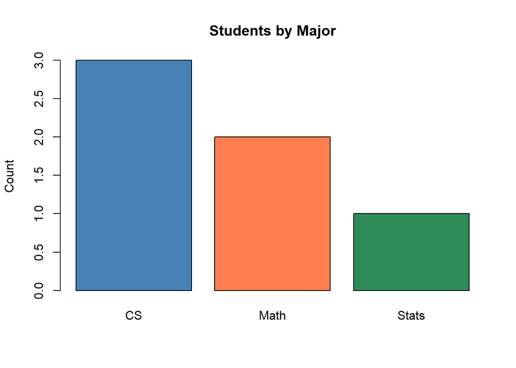

```r
counts <- table(students$major)
barplot(counts, col = c("steelblue", "coral", "seagreen"),
        main = "Students by Major", ylab = "Count")
```

### 3.5 Boxplot

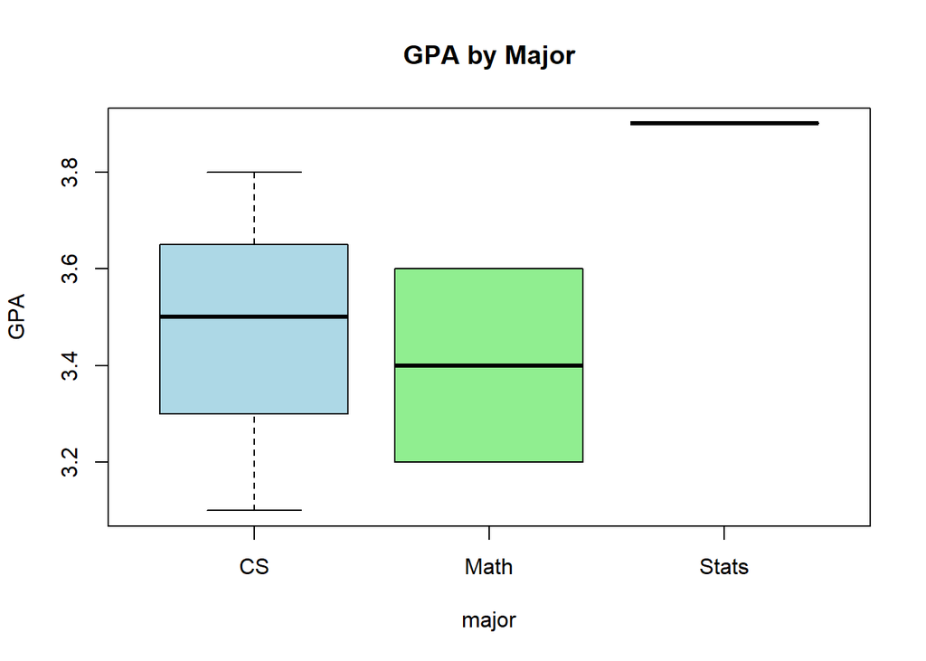

```r
boxplot(gpa ~ major, data = students,
        col = c("lightblue", "lightgreen", "lightyellow"),
        main = "GPA by Major", ylab = "GPA")
```

### 3.6 Multi-Panel Layouts

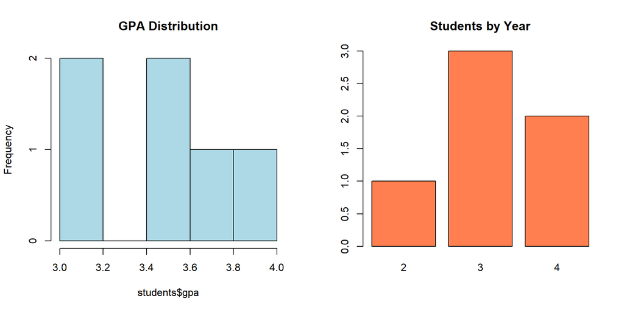

```r
par(mfrow = c(1, 2))
hist(students$gpa, col = "lightblue", main = "GPA Distribution")
barplot(table(students$year), col = "coral", main = "Students by Year")
```

```r
par(mfrow = c(1, 1))
```

### 3.7 Adding Layers

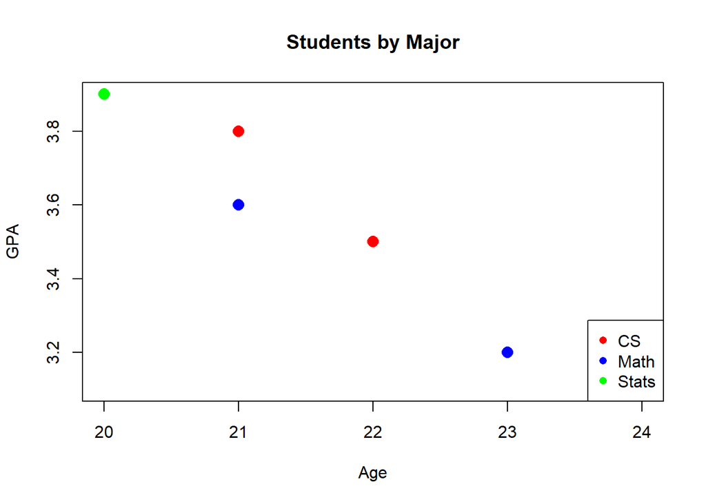

```r
plot(students$age, students$gpa, type = "n",
     main = "Students by Major", xlab = "Age", ylab = "GPA")

colors <- c(CS = "red", Math = "blue", Stats = "green")
for (m in unique(students$major)) {
  sub <- students[students$major == m, ]
  points(sub$age, sub$gpa, col = colors[m], pch = 16, cex = 1.5)
}
legend("bottomright", legend = names(colors), col = colors, pch = 16)
```

### Your Turn: Exercise 3.1

Create a histogram of 1000 random values from a normal distribution with mean=0, sd=1. Add a vertical line at the mean. Use `breaks = 30` and a color of your choice.

**Solution**

```r
set.seed(123)
data <- rnorm(1000)
hist(data, breaks = 30, col = "steelblue", border = "white",
     main = "Standard Normal", xlab = "Value")
abline(v = mean(data), col = "red", lwd = 2, lty = 2)
```

### Your Turn: Exercise 3.2

Create a 2x2 panel of plots using the `students` data:

1. Top left: scatter plot of age vs GPA
2. Top right: bar plot of major counts
3. Bottom left: boxplot of GPA by year
4. Bottom right: barplot of year counts

**Solution**

```r
par(mfrow = c(2, 2), mar = c(4, 4, 3, 1))
plot(students$age, students$gpa, pch = 16, col = "steelblue",
     main = "Age vs GPA", xlab = "Age", ylab = "GPA")
barplot(table(students$major), col = "coral", main = "Majors")
boxplot(gpa ~ year, data = students, col = "lightgreen", main = "GPA by Year")
barplot(table(students$year), col = "lightyellow", main = "Years")
par(mfrow = c(1, 1))
```

### Your Turn: Exercise 3.3

Create a scatter plot of `mtcars$wt` (weight) vs `mtcars$mpg` (fuel efficiency). Color the points by the number of cylinders (`mtcars$cyl`). Add a legend.

**Solution**

```r
colors <- c("4" = "blue", "6" = "green", "8" = "red")
plot(mtcars$wt, mtcars$mpg, pch = 16,
     col = colors[as.character(mtcars$cyl)],
     main = "Weight vs MPG by Cylinders",
     xlab = "Weight (1000 lbs)", ylab = "MPG")
legend("topright", legend = paste(names(colors), "cyl"),
       col = colors, pch = 16)
```

**TipChallenge**

Create a “dashboard” with 4 plots about the built-in `iris` dataset:

1. Scatter: Sepal.Length vs Sepal.Width colored by Species
2. Boxplot: Petal.Length by Species
3. Histogram: Petal.Width
4. Bar plot: count of each Species

Include titles, colors, and legends where appropriate.

**Solution**

```r
par(mfrow = c(2, 2), mar = c(4, 4, 3, 1))

# 1
cols <- c(setosa = "red", versicolor = "blue", virginica = "green")
plot(iris$Sepal.Length, iris$Sepal.Width, pch = 16,
     col = cols[iris$Species], main = "Sepal Dimensions",
     xlab = "Length", ylab = "Width")
legend("topright", legend = names(cols), col = cols, pch = 16, cex = 0.7)

# 2
boxplot(Petal.Length ~ Species, data = iris,
        col = c("lightcoral", "lightblue", "lightgreen"),
        main = "Petal Length by Species")

# 3
hist(iris$Petal.Width, breaks = 20, col = "steelblue",
     main = "Petal Width Distribution", xlab = "Width")

# 4
barplot(table(iris$Species), col = c("lightcoral", "lightblue", "lightgreen"),
        main = "Species Count")

par(mfrow = c(1, 1))
```

## Session Synthesis

### Connect the Dots

Build a text analysis of the `students` data using skills from all three parts:

1. Use `tapply` to compute mean GPA by major
2. Use `sprintf` to create a formatted report string for each major: “Major: X | Avg GPA: X.XX | Count: X”
3. Create a two-panel plot: (a) bar plot of mean GPA by major, (b) scatter plot of age vs GPA colored by major with legend
4. Use `mapply` to create student labels: “Name (Major, GPA: X.X)”

**Solution**

```r
# 1
avg_gpa <- tapply(students$gpa, students$major, mean)
counts <- tapply(students$name, students$major, length)

# 2
mapply(\(major, avg, n) {
  sprintf("Major: %s | Avg GPA: %.2f | Count: %d", major, avg, n)
}, names(avg_gpa), avg_gpa, counts)

# 3
par(mfrow = c(1, 2), mar = c(4, 4, 3, 1))
barplot(avg_gpa, col = "steelblue", main = "Mean GPA by Major",
        ylab = "GPA", ylim = c(0, 4))
colors <- c(CS = "red", Math = "blue", Stats = "green")
plot(students$age, students$gpa, pch = 16,
     col = colors[students$major],
     main = "Age vs GPA", xlab = "Age", ylab = "GPA")
legend("bottomright", legend = names(colors), col = colors, pch = 16)
par(mfrow = c(1, 1))

# 4
mapply(\(n, m, g) sprintf("%s (%s, GPA: %.1f)", n, m, g),
       students$name, students$major, students$gpa)
```

### Key Takeaways

1. Use `vapply` in scripts (type-safe), `sapply` in console (convenient), `tapply` for groups.
2. `paste()` concatenates, `sprintf()` formats, `grep()`/`gsub()` find and replace patterns.
3. Base R plots build in layers: start with `plot()`, add with `points()`, `lines()`, `legend()`.
4. `par(mfrow)` creates multi-panel layouts.

### Prepare for Next Session

**Session 4: Files, Errors, and Review**

We will read and write data files, handle errors with `tryCatch`, and do a cumulative review of Sessions 1-3. Make sure all concepts from today are solid.